# K-Nearest Neighbor (KNN) Regression on Boston Housing Dataset

### Load Packages

```r
library(MASS)
library(MLmetrics)
```

```r
library(caret)
```

Pada kasus regresi ini, akan digunakan data `Boston Housing` dengan rincian variabel sebagai berikut.

- `CRIM` : per capita crime rate by town
- `ZN` : proportion of residential land zoned for lots over 25,000 sq.ft.
- `INDUS` : proportion of non-retail business acres per town
- `CHAS` : Charles River dummy variable (1 if tract bounds river; 0 otherwise)
- `NOX` : nitric oxides concentration (parts per 10 million)
- `RM` : average number of rooms per dwelling
- `AGE` : proportion of owner-occupied units built prior to 1940
- `DIS` : weighted distances to five Boston employment centres
- `RAD` : index of accessibility to radial highways
- `TAX` : full-value property-tax rate per $10,000
- `PTRATIO` : pupil-teacher ratio by town
- `B` : 1000(Bk - 0.63)^2 where Bk is the proportion of blacks by town
- `LSTAT` : % lower status of the population
- `MEDV` : Median value of owner-occupied homes in $1000’s

```r
boston <- MASS::Boston
head(boston)
```

|  | crim | zn | indus | chas | nox | rm | age | dis | rad | tax | ptratio | black | lstat | medv |
| --- | --- | --- | --- | --- | --- | --- | --- | --- | --- | --- | --- | --- | --- | --- |
| 1 | 0.00632 | 18 | 2.31 | 0 | 0.538 | 6.575 | 65.2 | 4.0900 | 1 | 296 | 15.3 | 396.90 | 4.98 | 24.0 |
| 2 | 0.02731 | 0 | 7.07 | 0 | 0.469 | 6.421 | 78.9 | 4.9671 | 2 | 242 | 17.8 | 396.90 | 9.14 | 21.6 |
| 3 | 0.02729 | 0 | 7.07 | 0 | 0.469 | 7.185 | 61.1 | 4.9671 | 2 | 242 | 17.8 | 392.83 | 4.03 | 34.7 |
| 4 | 0.03237 | 0 | 2.18 | 0 | 0.458 | 6.998 | 45.8 | 6.0622 | 3 | 222 | 18.7 | 394.63 | 2.94 | 33.4 |
| 5 | 0.06905 | 0 | 2.18 | 0 | 0.458 | 7.147 | 54.2 | 6.0622 | 3 | 222 | 18.7 | 396.90 | 5.33 | 36.2 |
| 6 | 0.02985 | 0 | 2.18 | 0 | 0.458 | 6.430 | 58.7 | 6.0622 | 3 | 222 | 18.7 | 394.12 | 5.21 | 28.7 |

### Data Scaling

*Scaling* data dilakukan untuk variabel prediktor yang bukan kategorik.

```r
x_scaled <- scale(boston[,-c(4,14)])[,]
boston_scaled <- cbind(x_scaled,boston[,c(4,14)])

head(boston_scaled)
```

|  | crim | zn | indus | nox | rm | age | dis | rad | tax | ptratio | black | lstat | chas | medv |
| --- | --- | --- | --- | --- | --- | --- | --- | --- | --- | --- | --- | --- | --- | --- |
| 1 | -0.4193669 | 0.2845483 | -1.2866362 | -0.1440749 | 0.4132629 | -0.1198948 | 0.140075 | -0.9818712 | -0.6659492 | -1.4575580 | 0.4406159 | -1.0744990 | 0 | 24.0 |
| 2 | -0.4169267 | -0.4872402 | -0.5927944 | -0.7395304 | 0.1940824 | 0.3668034 | 0.556609 | -0.8670245 | -0.9863534 | -0.3027945 | 0.4406159 | -0.4919525 | 0 | 21.6 |
| 3 | -0.4169290 | -0.4872402 | -0.5927944 | -0.7395304 | 1.2814456 | -0.2655490 | 0.556609 | -0.8670245 | -0.9863534 | -0.3027945 | 0.3960351 | -1.2075324 | 0 | 34.7 |
| 4 | -0.4163384 | -0.4872402 | -1.3055857 | -0.8344581 | 1.0152978 | -0.8090878 | 1.076671 | -0.7521778 | -1.1050216 | 0.1129203 | 0.4157514 | -1.3601708 | 0 | 33.4 |
| 5 | -0.4120741 | -0.4872402 | -1.3055857 | -0.8344581 | 1.2273620 | -0.5106743 | 1.076671 | -0.7521778 | -1.1050216 | 0.1129203 | 0.4406159 | -1.0254866 | 0 | 36.2 |
| 6 | -0.4166314 | -0.4872402 | -1.3055857 | -0.8344581 | 0.2068916 | -0.3508100 | 1.076671 | -0.7521778 | -1.1050216 | 0.1129203 | 0.4101651 | -1.0422909 | 0 | 28.7 |

### Data Partition

Data dibagi menjadi 90% data *training* dan 10% data *testing*.

```r
indexes <- createDataPartition(boston$medv,p = .9,list = F)
train <- boston_scaled[indexes,]
test <-boston_scaled[-indexes,]

train_x <- train[,-14]
train_y <- train[,14]

test_x <- test[,-14]
test_y <- test[,14]
```

### KNN Regression

Pembentukan model regresi KNN dengan k = 5.

```r
knnmodel <- knnreg(train_x,train_y,k=5)

pred_y <- predict(knnmodel,data.frame(test_x))

mape_test <- MAPE(pred_y,test_y)*100
rmse_test <- caret::RMSE(test_y, pred_y)

cat("MAPE: ",mape_test,"RMSE: ",rmse_test)
```

```
MAPE:  12.03899 RMSE:  3.90785
```

### Plot Actual vs. Predicted Data

```r
x = 1:length(test_y)
plot(x, test_y, col = "red", type = "l", lwd=2,
     main = "Boston Housing Test Data Prediction")
lines(x, pred_y, col = "blue", lwd=2)
```

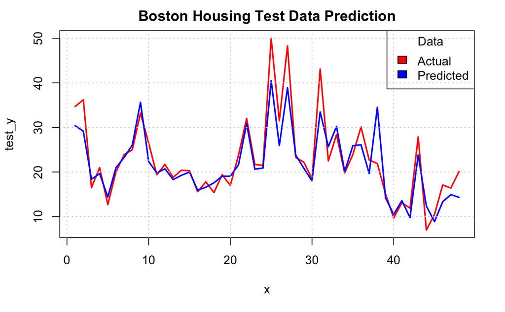

```r
legend("topright", title = "Data", legend = c("Actual", "Predicted"),
       fill = c("red", "blue"), col = 2:3,  adj = c(0, 0.6))
grid()
```